# Artificial Intelligence 🪐

# CA 2 - Hidden Markov Model (HMM)

# Amirali Shahriary (810100173)

## Intro:

Here we import the necessary libraries in the project:

```python
import os
import numpy as np
import librosa
import librosa.display
import matplotlib.pyplot as plt
from hmmlearn import hmm
from python_speech_features import mfcc
import scipy.io.wavfile as wav
from sklearn.metrics import confusion_matrix
import seaborn as sns
import matplotlib.pyplot as plt
from tabulate import tabulate
from sklearn.model_selection import train_test_split
from tabulate import tabulate
from scipy.stats import multivariate_normal
```

## Preprocessing:

### 1. Do you think data segmentation is useful for this dataset? Why?

Data segmentation can indeed be useful for this dataset. Since each audio file contains 50 repetitions of a single digit pronounced by a speaker, segmentation allows for isolating individual instances of digit pronunciations. This can help in reducing variability within each sample and making the training process more effective.

### 2. Research each of these features and explain the relationships between them (mfcc, Zero Crossing Rate , mel-spectrogram and chroma features) .

MFCC (Mel Frequency Cepstral Coefficients): These are coefficients that collectively represent the short-term power spectrum of a sound. MFCCs are derived from the Fourier Transform and are often used in speech and audio processing tasks due to their effectiveness in capturing relevant features of the sound signal.

Zero Crossing Rate: This feature measures the rate at which the signal changes its sign, which can provide information about the frequency content and periodicity of the signal.

Mel-Spectrogram: A spectrogram is a visual representation of the spectrum of frequencies of a signal as it varies with time. Mel spectrograms are spectrograms with frequencies converted to the mel scale, which approximates the human auditory system's response to frequencies.

Chroma Features: These features represent the energy distribution of pitch classes in a sound signal, which can be useful for tasks involving music and harmony analysis.

```python
data_dir = "/home/amirali/Desktop/AI/CA2/recordings"
digit_labels = list(range(10))

def extract_mfcc(audio_file, n_mfcc=13):
    (rate, sig) = wav.read(audio_file)
    mfcc_feat = mfcc(sig, rate, numcep=n_mfcc)
    return mfcc_feat
```

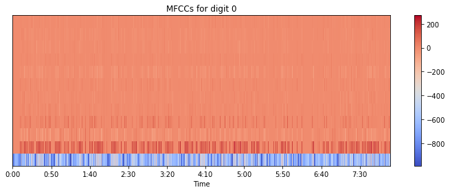

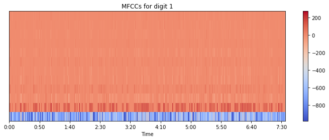

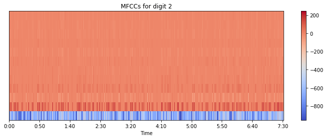

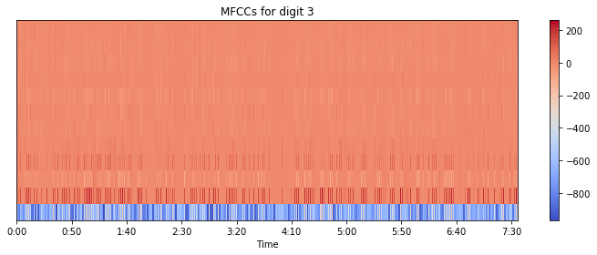

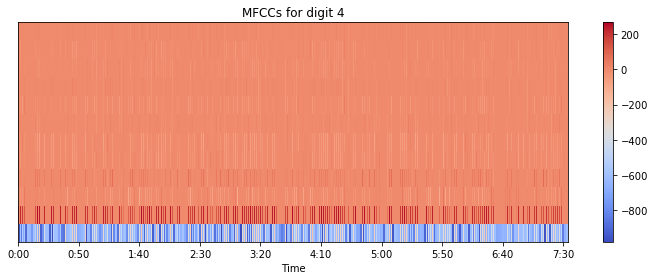

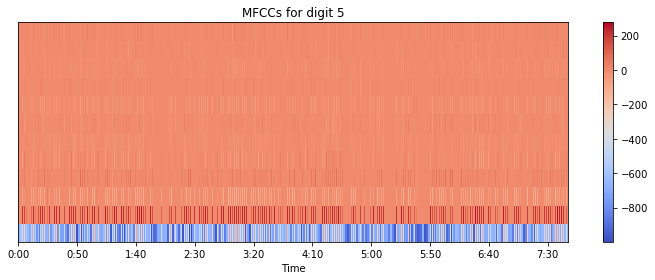

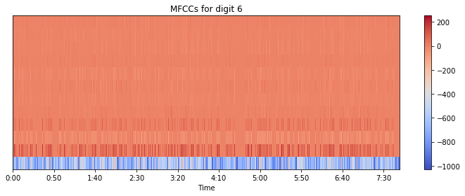

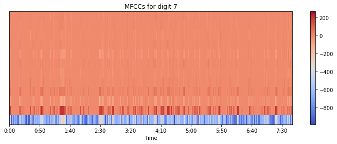

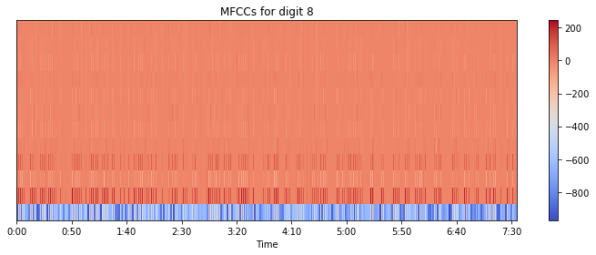

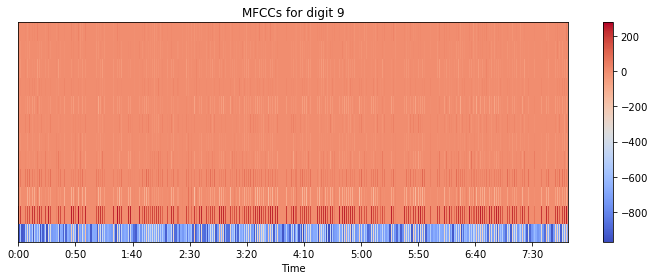

```python
def extract_mfcc_for_digit(digit, data_dir, n_mfcc=13):
    digit_files = [file for file in os.listdir(data_dir) if file.startswith(f"{digit}_")]
    mfccs_per_digit = []
    for file in digit_files:
        file_path = os.path.join(data_dir, file)
        y, sr = librosa.load(file_path)
        mfccs = librosa.feature.mfcc(y=y, sr=sr, n_mfcc=n_mfcc)
        mfccs_per_digit.append(mfccs)
    return np.concatenate(mfccs_per_digit, axis=1)  # concatenate mfcc arrays along axis 1

def plot_mfcc_heatmap_for_digit(mfccs, digit):
    plt.figure(figsize=(10, 4))
    librosa.display.specshow(mfccs, x_axis='time')
    plt.colorbar()
    plt.title(f"MFCCs for digit {digit}")
    plt.tight_layout()
    plt.show()

for digit in range(10):
    mfccs = extract_mfcc_for_digit(digit, data_dir)
    plot_mfcc_heatmap_for_digit(mfccs, digit)
```

### 3. Check the robustness and sensitivity of MFCCs characteristics to changes in audio signals.

MFCCs are generally robust to changes in audio signals such as background noise, pitch variations, and different speakers. However, their sensitivity to changes in audio signals can depend on factors such as the choice of parameters during feature extraction and the specific characteristics of the audio signal being analyzed.

### 4. Are there specific cases where MFCC coefficients are less effective?

MFCC coefficients may be less effective in cases where there are significant variations in the signal that are not well captured by the chosen parameters, such as highly variable background noise, non-stationary characteristics of the signal, or in cases where the signal deviates significantly from typical speech patterns.

### 5. Why do the frames used in MFCC calculation overlap with each other?

overlapping frames in MFCC extraction offers advantages in capturing temporal changes within the audio signal, thereby reducing variability and producing a smoother representation, which is advantageous for diverse audio analysis tasks. The use of MFCC frames structured as windows lasting through multiple frames enhances the representation of the audio file, leading to improved performance in audio processing and analysis.

### 6. Why are only 12 or 13 basic MFCC coefficients used in most audio-related projects?

because first 13 coefficients of MFCCs are used as they capture the most important information about the spectral envelope of the audio signal The first coefficient represents the overall energy of the signal, while the remaining 12 coefficients capture the spectral shape of the signal.This decision also will reduce dimensionality of our data to lower computational cost. Also, human voice is mostly covered in this range.

## Introduction to HMM :

### 1. Explain what is meant by States and Observation? What are the states in this exercise and how is observation obtained?

States: It means our hidden states, which our goal is to predict in which hidden state we are based of the observations we saw until now. Each state has a chance of moving to another state or staying there at each step. in this exercise states are the digits 0 through 9 that are being spoken by different speakers. Each state corresponds to a specific digit.

Observation: It means our evidences, which are our noisy observatin from the world and we only get to see those in our HMM.Difference between Markov and Hidden Markov is in observations.The observations are the MFCC coefficients extracted from the audio recordings of each spoken digit. These MFCC coefficients capture the acoustic features of the speech signals, which can be used to infer the underlying states (the spoken digits) through an HMM-based speech recognition system.

### 2. HMM models can be classified based on the degree of dependence between hidden states, the model you will implement in this exercise is an First-Order HMM model. Check out the reason for its name as well as its features and explain its difference from other models in this category.

First Order HMM also called the first-order Markov model is in a shape that each hidden state has one observation connected to it and hidden states are connected in the form of a simple Markov chain so that's why it is called first-order. This model is simple and only considers that the current state only depends on the past. It has a low computational cost. we can model many types of situations and works well when our sequence has a short-term dependency with this type of modeling. More complex models can be utilized to handle situations where our relations are not really simple. so in summary we can see Memoryless Transitions, Simplicity, and Stationarity in this modeling system.

There are also other types of modeling like : Second-Order HMM: The probability of the current state would depend on the two immediately preceding states Third-Order HMM: The probability of the current state would depend on the three immediately preceding states

### 3. Research about HMM and explain what phenomena this model is suitable for investigating and analyzing? Explain why this is the case.

HMM models are well-suited for analyzing and modeling phenomena characterized by sequential data and underlying hidden states. They are useful when working with sequential data like a series of events or a time series.

some example of using HMM:

- Speech Recognition : As speech can be modeled as a time series of sound waves like how we can see in this project.
- Natural Language Processing: Model the sequential nature of language and capture the dependencies between different words.
- Weather Forecasting: Can model weather sequences where states represent specific weather conditions and the observations might be related atmospheric measurements like temperature or wind.

### 4. The HMM model, like any other model, has advantages and disadvantages that make it special. Examine the advantages and disadvantages of this model and briefly explain each one.

Advantages:

- Flexibility of hmm has made it popular for wide range of problems and it is adapted to different domains and types of input data.
- has a high interpretability and we can easily understand it.
- Low computational cost.
- Provides a probabilistic framework which accounts for uncertainties in the observable data, as well as the state transitions.

Disadvatages:

- Simplicity of this model makes it limited for complex data.
- Requires sufficient amount of data for good results.
- Different initial parameters may lead to different answers and convergence to optimal parameters can be influenced by the quality of the initial estimates.
- The number of parameters grows quickly with the number of states, which can make the model complex and hard to train, especially with limited data.

### 5. There are different types of HMM models, research them and briefly review a few.

- Continuous:The observations are continuous distributions, often Gaussian. Continuous HMMs are used in applications where the data are real-valued, such as in econometrics or speech processing for modeling spectral coefficients.
- Mixture:It is a mixture of Gaussian distributions to model the observation probabilities. They are particularly useful in speech and audio processing where a single Gaussian distribution is not sufficient to model the complex variations in feature vectors.
- Hierarchical: Used when there exist a hierarchy in the sequence and each state captures some level of it.

## Implementing with Libraries:

target var = digital label

implemented with built-in library for confusion matrix.

```
Accuracy: 0.8766666666666667
```

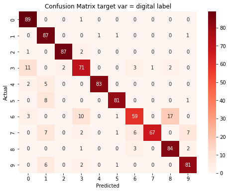

```python
def hmm_train(file_paths):
    hmm_model_results = []
    test_list = []

    for digit in digit_labels:
        x_train = np.array([])
        x_train_paths, x_test_paths = train_test_split(file_paths[digit], test_size=0.3, random_state=42)

        for k in range(len(x_test_paths)):
            test_list.append((x_test_paths[k], digit))

        for audio_file in x_train_paths:
            mfcc_features = extract_mfcc(audio_file)
            if x_train.size == 0:
                x_train = mfcc_features
            else:
                x_train = np.append(x_train, mfcc_features, axis=0)

        model = hmm.GaussianHMM(n_components=4, covariance_type='diag', n_iter=12)
        model.fit(x_train)
        hmm_model_results.append(model)

    return hmm_model_results, test_list


def evaluate(hmm_model_results, test_list, mode):
    accu = 0
    results = []

    for path, label in test_list:
        mfcc_features = extract_mfcc(path)
        model_scores = [model.score(mfcc_features) for model in hmm_model_results]
        predicted_digit = np.argmax(model_scores)
        results.append((predicted_digit, label))

        if label == predicted_digit:
            accu += 1

    c_matrix = confusion_matrix([x[1] for x in results], [x[0] for x in results])

    plt.figure(figsize=(8, 6))
    sns.heatmap(c_matrix, annot=True, cmap='Reds', fmt='d', xticklabels=digit_labels, yticklabels=digit_labels)
    plt.xlabel('Predicted')
    plt.ylabel('Actual')
    plt.title('Confusion Matrix target var = digital label')

    accu /= len(test_list)
    print(f"Accuracy: {accu}")

# file paths for each spoken digit
file_paths = {digit: [] for digit in digit_labels}
for file in os.listdir(data_dir):
    if file.endswith(".wav"):
        digit_label = int(file.split("_")[0])  #for extracting digit label from file name
        file_paths[digit_label].append(os.path.join(data_dir, file))

# Train
hmm_model_results, test_list = hmm_train(file_paths)

evaluate(hmm_model_results, test_list, mode="library hmm")
```

⚝⚝⚝⚝⚝⚝⚝⚝⚝⚝⚝⚝⚝⚝⚝⚝⚝⚝⚝⚝⚝⚝⚝⚝⚝⚝⚝⚝⚝⚝⚝⚝⚝⚝⚝⚝⚝⚝⚝⚝⚝⚝⚝⚝⚝⚝⚝⚝⚝⚝⚝⚝⚝⚝⚝⚝⚝⚝⚝⚝⚝⚝⚝⚝⚝⚝⚝⚝

target var = digital label

implemented without using built-in library for confusion matrix.

```
Confusion Matrix target var = digital label:
[[88  4  1 12  2  0  3  0  0  0]
 [ 0 74  0  0  3  5  0  0  0  0]
 [ 0  0 87  3  0  0  0  0  0  0]
 [ 1  0  2 69  0  0 10  5  1  2]
 [ 1  4  0  0 85  0  0  0  0  0]
 [ 0  1  0  0  0 84  0  2  0  1]
 [ 0  0  0  3  0  0 60  1  3  0]
 [ 0  2  0  1  0  0  0 76  0  1]
 [ 0  0  0  2  0  0 17  0 84  0]
 [ 0  5  0  0  0  1  0  6  2 86]]
Accuracy: 0.8811111111111111
Precision:
Digit 0: 0.8
Digit 1: 0.9024390243902439
Digit 2: 0.9666666666666667
Digit 3: 0.7666666666666667
Digit 4: 0.9444444444444444
Digit 5: 0.9545454545454546
Digit 6: 0.8955223880597015
Digit 7: 0.95
Digit 8: 0.8155339805825242
Digit 9: 0.86
```

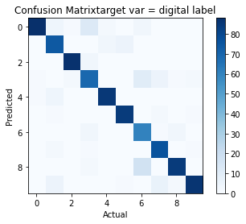

```python
def evaluate(hmm_model_results, test_list, mode):
    accu = 0
    results = []
    confusion_matrix = np.zeros((10, 10), dtype=int)

    for path, label in test_list:
        mfcc_features = extract_mfcc(path)
        model_scores = [model.score(mfcc_features) for model in hmm_model_results]
        predicted_digit = np.argmax(model_scores)
        results.append((predicted_digit, label))
        confusion_matrix[predicted_digit][label] += 1

        if label == predicted_digit:
            accu += 1

    accuracy = accu / len(test_list)

    precision = np.zeros(10)
    for i in range(10):
        if confusion_matrix[i][i] > 0:
            precision[i] = confusion_matrix[i][i] / sum(confusion_matrix[i])

    print("Confusion Matrix target var = digital label:")
    print(confusion_matrix)
    print(f"Accuracy: {accuracy}")
    print("Precision:")
    for i in range(10):
        print(f"Digit {i}: {precision[i]}")

    plt.imshow(confusion_matrix, cmap='Blues')
    plt.xlabel("Actual")
    plt.ylabel("Predicted")
    plt.title("Confusion Matrixtarget var = digital label")
    plt.colorbar()
    plt.show()

# Train
hmm_model_results, test_list = hmm_train(file_paths)

evaluate(hmm_model_results, test_list, mode="library hmm")
```

⚝⚝⚝⚝⚝⚝⚝⚝⚝⚝⚝⚝⚝⚝⚝⚝⚝⚝⚝⚝⚝⚝⚝⚝⚝⚝⚝⚝⚝⚝⚝⚝⚝⚝⚝⚝⚝⚝⚝⚝⚝⚝⚝⚝⚝⚝⚝⚝⚝⚝⚝⚝⚝⚝⚝⚝⚝⚝⚝⚝⚝⚝⚝⚝⚝⚝⚝⚝

target var = speaker Name

implemented without using built-in library for confusion matrix.

```
Confusion Matrix:
[[444   1   0   0  23   0]
 [ 10 495   0   0   0   2]
 [  0   0 497   0   1   1]
 [  0   0   0 500   1   3]
 [ 46   4   0   0 453   4]
 [  0   0   3   0  22 490]]
Accuracy: 0.9596666666666667
Precision:
Speaker yweweler: 0.9487179487179487
Speaker lucas: 0.9763313609467456
Speaker nicolas: 0.9959919839679359
Speaker george: 0.9920634920634921
Speaker theo: 0.893491124260355
Speaker jackson: 0.9514563106796117
```

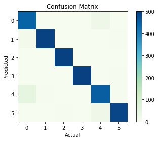

```python
def train_models_by_speaker(data_dir):
    speakers = set()
    speaker_files = {}
    for file in os.listdir(data_dir):
        if file.endswith(".wav"):
            speaker_name = file.split("_")[1]
            speakers.add(speaker_name)
            if speaker_name not in speaker_files:
                speaker_files[speaker_name] = []
            speaker_files[speaker_name].append(os.path.join(data_dir, file))

    hmm_models = {}
    for speaker in speakers:
        mfcc_features = np.array([])
        for file_path in speaker_files[speaker]:
            features = extract_mfcc(file_path)
            if mfcc_features.size == 0:
                mfcc_features = features
            else:
                mfcc_features = np.concatenate((mfcc_features, features), axis=0)
        model = hmm.GaussianHMM(n_components=4, covariance_type="diag", n_iter=100)
        model.fit(mfcc_features)
        hmm_models[speaker] = model

    return hmm_models, speaker_files

def evaluate_models(models, speaker_files):
    confusion_matrix = np.zeros((len(models), len(models)), dtype=int)
    total_samples = 0
    correct_predictions = 0
    for speaker, files in speaker_files.items():
        for file_path in files:
            total_samples += 1
            mfcc_features = extract_mfcc(file_path)
            scores = {target_speaker: model.score(mfcc_features) for target_speaker, model in models.items()}
            predicted_speaker = max(scores, key=scores.get)
            confusion_matrix[list(models.keys()).index(predicted_speaker)][list(models.keys()).index(speaker)] += 1
            if predicted_speaker == speaker:
                correct_predictions += 1

    accuracy = correct_predictions / total_samples

    precision = np.zeros(len(models))
    for i in range(len(models)):
        if confusion_matrix[i][i] > 0:
            precision[i] = confusion_matrix[i][i] / sum(confusion_matrix[i])

    print("Confusion Matrix:")
    print(confusion_matrix)
    print(f"Accuracy: {accuracy}")
    print("Precision:")
    for i, speaker in enumerate(models.keys()):
        print(f"Speaker {speaker}: {precision[i]}")

    plt.imshow(confusion_matrix, cmap='GnBu')
    plt.xlabel("Actual")
    plt.ylabel("Predicted")
    plt.title("Confusion Matrix")
    plt.colorbar()
    plt.show()

# Train
models, speaker_files = train_models_by_speaker(data_dir)
evaluate_models(models, speaker_files)
```

⚝⚝⚝⚝⚝⚝⚝⚝⚝⚝⚝⚝⚝⚝⚝⚝⚝⚝⚝⚝⚝⚝⚝⚝⚝⚝⚝⚝⚝⚝⚝⚝⚝⚝⚝⚝⚝⚝⚝⚝⚝⚝⚝⚝⚝⚝⚝⚝⚝⚝⚝⚝⚝⚝⚝⚝⚝⚝⚝⚝⚝⚝⚝⚝⚝⚝⚝⚝

## Implementing from Scratch:

implementing without using library target var = digital Label

```python
class HMM:
    def __init__(self, num_hidden_states):
        self.num_hidden_states = num_hidden_states
        self.rand_state = np.random.RandomState(1)

        self.initial_prob = self._normalize(self.rand_state.rand(1, self.num_hidden_states))
        self.transition_matrix = self._stochasticize(self.rand_state.rand(self.num_hidden_states, self.num_hidden_states))

        self.mean = None
        self.covariances = None
        self.num_dimensions = None

    def _forward(self, observation_matrix):
        log_likelihood = 0.
        T = observation_matrix.shape[1]
        alpha = np.zeros(observation_matrix.shape)
        for t in range(T):
            if t == 0:
                alpha[:, t] = self.initial_prob[:] * observation_matrix[:, t]
            else:
                alpha[:, t] = np.dot(alpha[:, t - 1], self.transition_matrix) * observation_matrix[:, t]

            alpha_sum = np.sum(alpha[:, t])
            alpha[:, t] /= alpha_sum
            log_likelihood += np.log(alpha_sum)

        return log_likelihood, alpha

    def _backward(self, observation_matrix):
        T = observation_matrix.shape[1]
        beta = np.zeros(observation_matrix.shape)

        beta[:, -1] = np.ones(observation_matrix.shape[0])

        for t in range(T - 1)[::-1]:
            beta[:, t] = np.dot(observation_matrix[:, t + 1], self.transition_matrix) * beta[:, t + 1]
            beta[:, t] /= np.sum(beta[:, t])

        return beta

    def _state_likelihood(self, obs):
        obs = np.atleast_2d(obs)
        B = np.zeros((self.num_hidden_states, obs.shape[1]))

        for s in range(self.num_hidden_states):
            np.random.seed(self.rand_state.randint(1))
            mean = self.mean[:, s]
            cov = self.covariances[:, :, s]
            B[s, :] = multivariate_normal.pdf(obs.T, mean=mean, cov=cov, allow_singular=True)

        return B

    def _normalize(self, x):
        return (x + (x == 0)) / np.sum(x)

    def _stochasticize(self, x):
        return (x + (x == 0)) / np.sum(x, axis=1)

    def _em_init(self, obs):
        if self.num_dimensions is None:
            self.num_dimensions = obs.shape[0]
        if self.mean is None:
            subset = self.rand_state.choice(np.arange(self.num_dimensions), size=self.num_hidden_states, replace=False)
            self.mean = obs[:, subset]
        if self.covariances is None:
            self.covariances = np.zeros((self.num_dimensions, self.num_dimensions, self.num_hidden_states))
            self.covariances += np.diag(np.diag(np.cov(obs)))[:, :, None]

        return self

    def _em_step(self, obs):
        obs = np.atleast_2d(obs)
        T = obs.shape[1]

        B = self._state_likelihood(obs)

        log_likelihood, alpha = self. _forward(B)

        beta = self._backward(B)

        xi_sum = np.zeros((self.num_hidden_states, self.num_hidden_states))
        gamma = np.zeros((self.num_hidden_states, T))

        for t in range(T - 1):
            partial_sum = (alpha[:, t] * self.transition_matrix.T).T * B[:, t + 1] * beta[:, t + 1]
            xi_sum += self._normalize(partial_sum)

            partial_g = alpha[:, t] * beta[:, t]
            gamma[:, t] = self._normalize(partial_g)

        partial_g = alpha[:, -1] * beta[:, -1]
        gamma[:, -1] = self._normalize(partial_g)


        expected_prior = gamma[:, 0]

        gamma_sum = np.repeat(np.sum(xi_sum, axis=1)[:, np.newaxis], axis=1, repeats=self.num_hidden_states)
        expected_transition = self._stochasticize(xi_sum / gamma_sum)

        expected_covariances = np.zeros((self.num_dimensions, self.num_dimensions, self.num_hidden_states))
        expected_covariances += .01 * np.eye(self.num_dimensions)[:, :, None]

        gamma_state_sum = np.sum(gamma, axis=1)
        gamma_state_sum = gamma_state_sum + (gamma_state_sum == 0)

        expected_mean = np.zeros((self.num_dimensions, self.num_hidden_states))
        for s in range(self.num_hidden_states):
            gamma_obs = obs * gamma[s, :]
            expected_mean[:, s] = np.sum(gamma_obs, axis=1) / gamma_state_sum[s]

        self.initial_prob = expected_prior
        self.mean = expected_mean
        self.covariances = expected_covariances
        self.transition_matrix = expected_transition

        return log_likelihood

    def train(self, obs, num_iterations=1):
        for i in range(num_iterations):
            self._em_init(obs)
            self._em_step(obs)
        return self

    def score(self, obs):
        B = self._state_likelihood(obs)
        log_likelihood, _ = self._forward(B)
        return log_likelihood
```

```
Confusion Matrix (target bar = digital Label):
[[27  0  0  3  7  3  0  5  2  4]
 [ 6 56  0  0 63 31  0 19  1 19]
 [49 16 83 71 11  9 56 26 41 24]
 [ 2  0  4  3  0  0  0  0  0  0]
 [ 0  0  0  0  2  0  0  0  0  0]
 [ 0  3  0  0  7 43  1  5  0  5]
 [ 0  1  1  1  0  0 15  2  0  0]
 [ 0  2  1  0  0  0  2 10  0  1]
 [ 3  3  1 12  0  0 15  1 46  2]
 [ 3  9  0  0  0  4  1 22  0 35]]
Accuracy: 0.35555555555555557
Precision:
Digit 0: 0.3
Digit 1: 0.6222222222222222
Digit 2: 0.9222222222222223
Digit 3: 0.03333333333333333
Digit 4: 0.022222222222222223
Digit 5: 0.4777777777777778
Digit 6: 0.16666666666666666
Digit 7: 0.1111111111111111
Digit 8: 0.5111111111111111
Digit 9: 0.3888888888888889
```

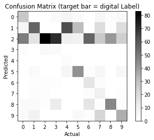

```python
def scratch_hmm(file_paths):
    hmm_model_results = []
    test_list = []
    for digit in digit_labels:
        x_train = np.array([])
        x_train_paths, x_test_paths = train_test_split(file_paths[digit], test_size=0.3, random_state=42)

        for k in range(len(x_test_paths)):
            test_list.append((x_test_paths[k], digit))

        for audio_file in x_train_paths:
            mfcc_features = extract_mfcc(audio_file)
            if x_train.size == 0:
                x_train = mfcc_features
            else:
                x_train = np.append(x_train, mfcc_features, axis=0)
        model = HMM(4)
        model.train(x_train.T / np.amax(x_train.T), 2)
        hmm_model_results.append(model)
    return hmm_model_results, test_list

def evaluate(hmm_model_results, test_files):
    accu = 0
    results = []
    confusion_matrix = np.zeros((10, 10), dtype=int)
    digit_counts = np.zeros(10, dtype=int)

    for path, label in test_files:
        mfcc_features = extract_mfcc(path)
        model_scores = [model.score(mfcc_features.T / np.amax(mfcc_features.T)) for model in hmm_model_results]
        predicted_digit = np.argmax(model_scores)
        results.append((predicted_digit, label))
        confusion_matrix[predicted_digit][label] += 1

        if label == predicted_digit:
            accu += 1

        digit_counts[label] += 1

    accuracy = accu / len(test_files)

    precision = np.zeros(10)
    for i in range(10):
        if confusion_matrix[i][i] > 0 and digit_counts[i] > 0:
            precision[i] = confusion_matrix[i][i] / digit_counts[i]
        else:
            precision[i] = 0  # precision to 0 or N/A if denominator is 0

    print("Confusion Matrix (target bar = digital Label):")
    print(confusion_matrix)
    print(f"Accuracy: {accuracy}")
    print("Precision:")
    for i in range(10):
        print(f"Digit {i}: {precision[i]}")

    plt.imshow(confusion_matrix, cmap='Greys')
    plt.xlabel("Actual")
    plt.ylabel("Predicted")
    plt.title("Confusion Matrix (target bar = digital Label)")
    plt.xticks(ticks=np.arange(10), labels=digit_labels)
    plt.yticks(ticks=np.arange(10), labels=digit_labels)
    plt.colorbar()
    plt.show()

    #plt.bar(np.arange(10), digit_counts, tick_label=digit_labels)
    #plt.xlabel("Digit")
    #plt.ylabel("Count")
    #plt.title("Data Distribution")
    #plt.show()

#training and testing sets
test_list = []
for digit, paths in file_paths.items():
    _, test_files = train_test_split(paths, test_size=0.3, random_state=42)
    test_list.extend([(file, digit) for file in test_files])

hmm_model_results, _ = scratch_hmm(file_paths)
evaluate(hmm_model_results, test_list)
```

⚝⚝⚝⚝⚝⚝⚝⚝⚝⚝⚝⚝⚝⚝⚝⚝⚝⚝⚝⚝⚝⚝⚝⚝⚝⚝⚝⚝⚝⚝⚝⚝⚝⚝⚝⚝⚝⚝⚝⚝⚝⚝⚝⚝⚝⚝⚝⚝⚝⚝⚝⚝⚝⚝⚝⚝⚝⚝⚝⚝⚝⚝⚝⚝⚝⚝⚝⚝

target var = speaker Name

```
Confusion Matrix (target bar = Speaker Name):
[[ 24  45   0  13   5  15]
 [  0  77   0   0   0   0]
 [ 91   0 148  43 109  51]
 [  1   7   0  81   0  13]
 [ 34  21   2  13  35  60]
 [  0   0   0   0   1  11]]
Accuracy: 0.4177777777777778
Precision:
Speaker yweweler: 0.16
Speaker lucas: 0.5133333333333333
Speaker nicolas: 0.9866666666666667
Speaker george: 0.54
Speaker theo: 0.23333333333333334
Speaker jackson: 0.07333333333333333
```

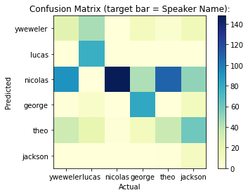

```python
def scratch_speaker_hmm(file_paths):
    hmm_model_results = []
    test_list = []
    for speaker in speaker_names:
        x_train = np.array([])
        x_train_paths, x_test_paths = train_test_split(file_paths[speaker], test_size=0.3, random_state=42)

        for k in range(len(x_test_paths)):
            test_list.append((x_test_paths[k], speaker))

        for audio_file in x_train_paths:
            mfcc_features = extract_mfcc(audio_file)

            if x_train.size == 0:
                x_train = mfcc_features
            else:
                x_train = np.append(x_train, mfcc_features, axis=0)


        model = HMM(4)
        model.train(x_train.T / np.amax(x_train.T), 2)
        hmm_model_results.append(model)
    return hmm_model_results, test_list

def evaluate(hmm_model_results, test_files):
    correct_predictions = 0
    results = []
    confusion_matrix = np.zeros((len(speaker_names), len(speaker_names)), dtype=int)
    speaker_to_index = {speaker: i for i, speaker in enumerate(speaker_names)}  # map speaker names to int

    # Count  of each speaker in the test files
    speaker_counts = np.zeros(len(speaker_names))
    for _, speaker in test_files:
        speaker_counts[speaker_to_index[speaker]] += 1

    for path, speaker in test_files:
        mfcc_features = extract_mfcc(path)
        model_scores = [model.score(mfcc_features.T / np.amax(mfcc_features.T)) for model in hmm_model_results]
        predicted_speaker = np.argmax(model_scores)
        results.append((predicted_speaker, speaker))
        confusion_matrix[predicted_speaker][speaker_to_index[speaker]] += 1  # Use integer index for speaker

        if speaker == predicted_speaker:
            correct_predictions += 1




    precision = np.zeros(len(speaker_names))
    for i, speaker in enumerate(speaker_names):
        if speaker_counts[i] > 0:
            precision[i] = confusion_matrix[i][i] / speaker_counts[i]
        else:
            precision[i] = 0  #  precision to 0 or N/A if denominator is 0
    accuracy = np.mean(precision)
    print("Confusion Matrix (target bar = Speaker Name):")
    print(confusion_matrix)
    print(f"Accuracy: {accuracy}")
    print("Precision:")
    for i, speaker in enumerate(speaker_names):
        print(f"Speaker {speaker}: {precision[i]}")

    plt.imshow(confusion_matrix, cmap='YlGnBu')
    plt.xlabel("Actual")
    plt.ylabel("Predicted")
    plt.title("Confusion Matrix (target bar = Speaker Name):")
    plt.xticks(ticks=np.arange(len(speaker_names)), labels=speaker_names)
    plt.yticks(ticks=np.arange(len(speaker_names)), labels=speaker_names)
    plt.colorbar()
    plt.show()

    #plt.bar(np.arange(len(speaker_names)), speaker_counts, tick_label=speaker_names)
    #plt.xlabel("Speaker")
    #plt.ylabel("Count")
    #plt.title("Data Distribution")
    #plt.show()

speaker_names = set()
for file in os.listdir(data_dir):
    if file.endswith(".wav"):
        speaker_name = file.split("_")[1]
        speaker_names.add(speaker_name)


file_paths = {speaker: [] for speaker in speaker_names}
for file in os.listdir(data_dir):
    if file.endswith(".wav"):
        speaker_name = file.split("_")[1]
        file_paths[speaker_name].append(os.path.join(data_dir, file))

# training and testing sets
test_list = []
for speaker, paths in file_paths.items():
    _, test_files = train_test_split(paths, test_size=0.3, random_state=42)
    test_list.extend([(file, speaker) for file in test_files])

hmm_model_results, _ = scratch_speaker_hmm(file_paths)

evaluate(hmm_model_results, test_list)
```

⚝⚝⚝⚝⚝⚝⚝⚝⚝⚝⚝⚝⚝⚝⚝⚝⚝⚝⚝⚝⚝⚝⚝⚝⚝⚝⚝⚝⚝⚝⚝⚝⚝⚝⚝⚝⚝⚝⚝⚝⚝⚝⚝⚝⚝⚝⚝⚝⚝⚝⚝⚝⚝⚝⚝⚝⚝⚝⚝⚝⚝⚝⚝⚝⚝⚝⚝⚝

## Evaluation and analysis:

### 1&3.There are many criteria to measure and evaluate the performance of models; For example: F1, Recall, Precision, Accuracy. Score Research each of the above criteria and explain how to calculate each one. - Explain how each of the criteria evaluates the model.

- Accuracy: It measures the overall correctness of the model predictions. It is calculated as the ratio of the number of correct predictions to the total number of data. It can be misleading when there is an imbalanced dataset:

$$\ \text{Accuracy} = \frac{\text{Number of Correct Predictions}}{\text{Total Number of Predictions}} =\frac{\text{True Positive} + \text{True Negative}}{\text{True Positive} + \text{True Negative} + \text{False Positive} + \text{False Negative}} \$$

- Precision : Quantifies the percentage of positive identifications by the model that are indeed accurate and valid. It is determined by the fraction of true positives relative to the aggregate of true positives and false positives.particularly in the context of binary classification problems.

$$ \text{Precision} = \frac{\text{True Positives}}{\text{True Positives + False Positives}} \$$

- Recall:Assesses the ability of a model to correctly capture all actual instances of a particular class; it’s the fraction of true positives out of the total actual positives, measuring how often the model misses true cases. In the context of HMMs, it reflects the model’s accuracy in identifying the correct sequence of states.it should be considered alongside other metrics (such as precision and F1 score) to comprehensively evaluate a model's performance in different aspects.

- F1-score:Harmonizes precision and recall into a single metric by taking their harmonic mean; it gives a balance between a model’s ability to accurately label true positives without wrongly labeling negatives.ombines precision and recall into a single value, providing a balanced measure of a model's performance in binary classification problems. It is especially useful when seeking an equilibrium between the precision and recall performance of a classifier.

$$ \text{F1 score} = \frac{2 \times (\text{Precision} \times \text{Recall})}{\text{Precision} + \text{Recall}} $$

### 2.Is it a challenge to calculate the mentioned criteria for this project which is class-multi? If yes, what solution do you have for it?

yes its challengive ;Macro, micro, and weighted averaging are commonly used techniques to calculate evaluation criteria for multi-class classification tasks like speaker recognition. Here's how they can be applied:

Macro Averaging: This method calculates the metric independently for each class and then takes the average across all classes. It treats all classes equally, regardless of their frequency in the dataset.

Micro Averaging: Micro averaging aggregates the contributions of all classes before computing the metric. It considers each instance equally, making it suitable for imbalanced datasets where some classes have significantly fewer samples.

Weighted Averaging: Weighted averaging assigns weights to each class based on their frequency in the dataset. It computes the metric for each class and then takes a weighted average, with weights proportional to the class frequency. This approach ensures that classes with more samples have a greater impact on the overall metric.

### 4. State the difference between Recall and Precision and explain why each alone is not sufficient to evaluate the model? For each, give an example where this criterion has a high value but the model does not perform well.

Precision and Recall are vital metrics for evaluating classification models. Precision measures the proportion of correctly predicted positive instances out of all instances predicted as positive, while Recall measures the proportion of correctly predicted positive instances out of all truly positive instances.

For example, imagine a dataset with 10 samples, where 7 are positive. If our model correctly predicts all 7 positive samples, Precision would be 0.7, indicating 70% of positive predictions were accurate. Meanwhile, Recall would be 1, as all true positive samples were identified. This highlights the significance of both metrics in evaluating model performance.

Conversely, if our model correctly predicts only one positive sample out of 7, with the rest labeled as negative, Precision would be 1 (no false positives), but Recall would be 0.14 (only 14% of true positives were identified).

Considering both Precision and Recall together provides a comprehensive view of model effectiveness. High Recall but low Precision, as seen in disease screening labeling all tests as "disease present," catches all cases but flags healthy individuals incorrectly. Conversely, high Precision but low Recall, like in identifying specific spam emails, may miss many other spam emails, resulting in poor performance.

### 5. What kind of averaging does F1 measure use? What is the difference between this type of averaging and normal averaging and why is it important here?

The F1 score uses the harmonic mean, making it suitable for skewed distributions or datasets with rates and ratio, which is less sensitive to extreme values.This approach ensures that the F1 score accurately reflects model performance across imbalanced datasets by requiring high precision and recall simultaneously.

### 8.Check the difference in the results of sections 6 and 7( two way of implementation) and identify the causes.

in implementation with library:

- Utilizes the hmmlearn library for pre-implemented HMMs.
- Features are extracted using MFCC similar to the manual approach.
- Data splitting, model training, and evaluation are handled using scikit-learn utilities.
- Provides a standardized framework for consistent results and efficient experimentation.
- Differences in default parameters, convergence criteria, or initialization strategies may impact results.

  in implementing from scratch:
- Requires manual definition and training of HMMs for each speaker.
- Involves manual feature extraction using MFCC.
- Data splitting and model training are performed manually.
- May have variations in parameter tuning, model architecture, or training procedure.
- Lower accuracy be due to suboptimal parameter choices, lack of advanced techniques like cross-validation, or variations in data preprocessing.